# TOSCA Version 2.0

## 15.1 Substitution Mapping

The `substitution_mapping` section in a service template serves four purposes:

1. It identifies the nodes for which the service template is a substitution candidate by specifying a node type and an associated substitution filter.
2. It defines how configuration and state values flow between the substituted node and the substituting template: property mappings specify how configuration values are propagated from the substituted node to the substituting service, and attribute mappings specify how runtime values are propagated back from the substituting service to the substituted node.
3. It dictates how the topology graph of the substituting service is *stitched in* to the top-level topology graph that contains the substituted node (using requirement and capability mappings).
4. It specifies how interface operations called on the substituted node are implemented using workflows on the substituting service, and how events generated in the substituting service are escalated to notifications on the substituted node.

Note that while capabilities and relationships may define properties and attributes, capability mappings and requirement mappings do not propagate these values. Capability and requirement mappings are used exclusively to control service topology. If capability or relationship values must be passed between the substituted node and its substituting service, property and attribute mappings must be used to define how these values are mapped.

| Keyname | Mandatory | Type | Description |
| --- | --- | --- | --- |
| `node_type` | yes | str | The name of the node type of the nodes for which the service template can provide an implementation. |
| `substitution_filter` | no | condition clause | The filter that further constrains the nodes for which this service template can provide an implementation. For a node that needs to be substituted, the condition clause specified by the substitution … |
| `properties` | no | map of property mappings | The map of property mappings that map properties of the substituted node to inputs of the service template. |
| `attributes` | no | map of attribute mappings | The map of attribute mappings that map outputs from the service template to attributes of the substituted node. |
| `capabilities` | no | map of capability mappings | The map of capability mappings. |
| `requirements` | no | seq of requirement mappings | The list of requirement mappings. |
| `interfaces` | no | map of interfaces mappings | The map of interface mappings that map interface operations called on the substituted node to implementations workflows on the substituting service. |

The grammar of the `substitution_mapping` section is as follows:

```yaml
node_type: <node_type_name>
substitution_filter: <substitution_filter>
properties:
  <property_mapping_1>
  <property_mapping_2>
  ...
attributes:
  <attribute_mapping_1>
  <attribute_mapping_2>
  ...
capabilities:
  <capability_mapping_1>
  <capability_mapping_2>
  ...
requirements:
- <requirement_mapping_1>
- <requirement_mapping_2>
- ...
interfaces:
  <interface_mapping_1>
  <interface_mapping_2>
  ...
```

In the above grammar, the placeholders that appear in angle brackets have the following meaning:

- `<node_type_name>`: represents the node type name for which the service template can offer an implementation.
- `<substitution_filter>`: represents a filter that reduces the set of nodes for which this service template is an implementation by only substituting for those nodes whose properties and capabilities satisfy the condition clause specified in the filter.
- `<property_mapping_*>`: represents the map of *property to input* mappings.
- `<attribute_mapping_*>`: represents the map of *output to attribute* mappings.
- `<capability_mapping_*>`: represents the map of capability mappings.
- `<requirement_mapping_*>`: represents the list of requirement mappings.
- `<interface_mapping_*>`: represents the map of interface mappings.

Please note:

- A substituting service template MUST be a valid TOSCA template in its own right (i.e., when not used as a substituting implementation). Specifically, all the required properties of all its node templates must have valid property assignments.

## 15.2 Property Mapping

A *property mapping* allows a property value of a substituted node to be mapped to an input value of the substituting service template.

The grammar of a property mapping is as follows:

```yaml
<property_name>: <input_name>
[ CAPABILITY, <capability_name>, <property_name> ]: <input_name>
[ RELATIONSHIP, <requirement_name>, <idx>, <property_name> ]: <input_name>
```

In the above grammar, the placeholders that appear in angle brackets have the following meaning:

- `<input_name>`: represents the name of an input defined for the substituting service template.
- `<property_name>`: represents the name of a property of the substituted node (defined using a corresponding property definition in the specified node type), or a property of a capability, or a property of a relationship created by a requirement of the substituted node.
- `<capability_name>`: represents the name of the capability as it appears in the node type definition for the substituted node
- `<requirement_name>`: represents the name of the requirement as it appears in the node type definition for the substituted node
- `<idx>`: index of the relationship defined from that requirement (0 is the first index); if the index is missing, index 0 is assumed; if the value ALL is used by as index, the corresponding input will be assigned a list of all values of properties with `<property_name>` from all relationships created from the requirement with `<requirement_name>`.

The following additional requirements apply:

- Mappings must be type-compatible (i.e., properties mapped to input must have the type specified in the corresponding input definition).
- Property mappings must be defined for all non-optional service template inputs that do not define a `default` value.

## 15.3 Attribute Mapping

An attribute mapping allows an output value of the substituting service template to be mapped to an attribute of the substituted node.

The grammar of an attribute mapping is as follows:

```yaml
<attribute_name>: <output_name>
[ CAPABILITY, <capability_name>, <attribute_name> ]: <output_name>
[ RELATIONSHIP, <requirement_name>, <idx>, <attribute_name> ]: <output_name>
```

In the above grammar, the placeholders that appear in angle brackets have the following meaning:

- `<output_name>`: represents the name of an output defined in the substituting service template.
- `<attribute_name>`: represents the name of an attribute of the substituted node (defined using a corresponding attribute definition in the specified node type) or an attribute of a capability, or an attribute of a relationship created by a requirement of the substituted node.
- `<capability_name>`: represents the name of the capability as it appears in the node type definition for the substituted node
- `<requirement_name>`: represents the name of the requirement as it appears in the node type definition for the substituted node
- `<idx>`: index of the relationship defined from that requirement (0 is the first index); if the index is missing, index 0 is assumed; if the value ALL is used by as index, all attributes with `<attribute_name>` from all relationships created from the requirement with `<requirement_name>` will be assigned a coresponding value from the output which is of a list type.

The following additional requirements apply:

- Mappings must be type-compatible (i.e., outputs mapped to attributes must have the type specified in the corresponding attribute definition).

## 15.4 Capability Mapping

A *capability mapping* allows a capability of one of the nodes in the substituting service template to be mapped to a capability of the substituted node.

The grammar of a capability mapping is as follows:

```yaml
<capability_name>: [ <node_template_name>, <node_template_capability_name> ]
```

In the above grammar, the placeholders that appear in angle brackets have the following meaning:

- `<capability_name>`: represents the name of the capability as it appears in the node type definition for the substituted node.
- `<node_template_name>`: represents a valid name of a node template definition within the substituting service template.
- `<node_template_capability_name>`: represents a valid name of a capability definition within the `<node_template_name>` declared in this mapping.

## 15.5 Requirement Mapping

A *requirement mapping* defines how requirements of the substituted node are mapped to one or more requirements of nodes in the substituting service. The term *requirement mapping* is somewhat of a misnomer, since mapping a requirement results in the target node of that requirement also being used as the target node for the *mapped* requirement. As a result, requirement mappings are a mechanism for passing nodes between templates.

The grammar for requirement mapping differs slightly from other substitution mapping grammars for the following two reasons:

1. It is possible for a substituted node to have multiple requirement assignments (up to the upper bound of the `count_range`), each of which may need to be mapped separately.
2. It is possible for the same requirement in a substituted node to be mapped multiple times.

To accommodate these use cases, requirement mappings are defined using YAML sequences rather than maps. In addition, each of the mappings in the sequences may in turn identify a sequence of requirements.

The grammar for requirement mappings is as follows:

```yaml
<requirement_name>:
- [ <node_template_name_1>, <node_template_requirement_name_1> ]
- [ <node_template_name_2>, <node_template_requirement_name_2> ]
- ...
```

If the substituting template uses *selectable* nodes to define requirements, then the following alternative syntax can be used:

```yaml
<requirement_name>:
- <selectable_node_template_name_1>
- <selectable_node_template_name_2>
- ...
```

The TOSCA grammar allows mixing and matching these two alternative syntaxes within the same requirement mappings list.

As an optimization, if the requirement mapping defines a *one-to-one* mapping (i.e., a mapping of a requirement onto a single requirement of a single node in the substituting template or a mapping to a single selectable node), the following single-line grammar may be used:

```yaml
<requirement_name>: [ <node_template_name>, <node_template_requirement_name> ]
```

or

```yaml
<requirement_name>: <selectable_node_template_name>
```

If we have several requirement mappings with the same requirement name (i.e. as the key of the requirement mapping) that means that each requirement assignment is mapped separately (in the order they appear in the list). If there is only one requirement mapping with a certain requirement name (i.e. as the key of the requirement mapping) then it means that all requirements assignments of that requirement are mapped to the same target requirement(s).

In the above grammars, the placeholders that appear in angle brackets have the following meaning:

- `<requirement_name>`: represents the name of the requirement as it appears in the type definition for the node type name that is declared as the value for on the substitution_mappings' `node_type` keyname.
- `<node_template_name>`: represents a valid name of a node template definition within the same substituting service template
- `<selectable_node_template_name>`: represents a valid name of a selectable node template definition within the same substituting service template.
- `<node_template_requirement_name>`: represents a valid name of a requirement definition within the `<node_template_name>` declared in this mapping.
- `<count>`: is the number of assignments of a requirement mapped to the same target requirement(s). It can be either a non-negetive integer or the value `UNBOUNDED`, which represents all the remaining assignments. Note that mappings with count can interspread mappings without count for the same requirement_name, however no other assignment for the same requirement_name should not be used after one containing an `UNBOUNDED` count.

The following subsections illustrate this grammar in the context of various use cases.

### 15.5.1 Mapping Multiple Requirements with the Same Name

The following example shows a "Client" node type that defines a "service" requirement with a `count_range` of "[2, 2]", which means that nodes of type "Client" need exactly two "service" relationships to nodes of type "Server".

```yaml
tosca_definitions_version: tosca_2_0
capability_types:
  Service:
    description: >-
      Ability to provide service.
relationship_types:
  ServedBy:
    description: >-
      Connection to a service.
node_types:
  Client:
    requirements:
    - service:
        capability: Service
        relationship: ServedBy
        node: Server
        count_range: [ 2, 2 ]
  Server:
    capabilities:
      service:
        type: Service
```

This following figure shows a service that consists of one such client node connected to two server nodes.

**Figure 19: Single Client Connected to Two Servers**

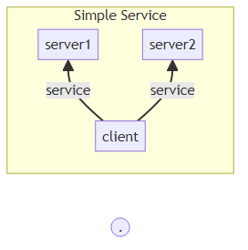

This service can be implemented using the following TOSCA service template:

```yaml
tosca_definitions_version: tosca_2_0
imports:
  - types.yaml
service_template:
  node_templates:
    server1:
      type: Server
    server2:
      type: Server
    client:
      type: Client
      directives: [ substitute ]
      requirements:
      - service: server1
      - service: server2
```

In this template, the "client" node is annotated with the "substitute" directive, which means that a substituting template must be found to instantiate this node. The following figure shows one possible substitution.

**Figure 20: Example Substitution for Client Connected to Two Servers**

[figure not shown]

This substitution decomposes the "client" node into two different "software" nodes, each with exactly one "service" requirement. The requirement mapping syntax must *distribute* the two "service" requirements from the substituted "client" node between the "service" requirements of the two software nodes in the substituting template. The substitution mapping code in the following substituting service template shows how this is accomplished:

```yaml
tosca_definitions_version: tosca_2_0
imports:
- types.yaml
capability_types:
  Host:
    description: >-
      Ability to host software.
relationship_types:
  HostedOn:
    description: >-
      Relationship to a host.
node_types:
  ClientSoftware:
    requirements:
    - host:
        capability: Host
        relationship: HostedOn
    - service:
        capability: ServiceCapability
        relationship: Uses
        count_range: [ 1, 1 ]
  Compute:
    capabilities:
      host:
        type: Host
service_template:
  substitution_mappings:
    node_type: Client
    requirements:
    - service: [ software1, service ]
    - service: [ software2, service ]
  node_templates:
    software1:
      type: ClientSoftware
      requirements:
      - host: compute1
    software2:
      type: ClientSoftware
      requirements:
      - host: compute2
    compute1:
      type: Compute
    compute2:
      type: Compute
```

The following figure shows an alternative substitution where both "service" requirements of the substituted "client" node are mapped to corresponding requirements of a single "software" node in the substituting topology:

**Figure 21: Alternative Substitution for Client Connected to Two Servers**

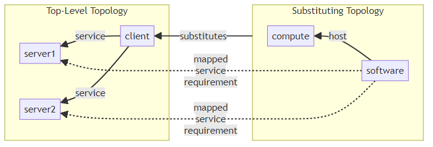

The requirement mapping syntax for this template distributes the two "service" requirements from the substituted "client" node to *the same* software node in the substituting template using two identical mappings for the two "service" requirements as follows:

```yaml
tosca_definitions_version: tosca_2_0

imports:
- types.yaml

capability_types:
  Host:
    description: >-
      Ability to host software.

relationship_types:
  HostedOn:
    description: >-
      Relationship to a host.

node_types:
  ClientSoftware:
    requirements:
    - host:
        capability: Host
        relationship: HostedOn
    - service:
        capability: ServiceCapability
        relationship: Uses
        count_range: [ 2, 2 ]

  Compute:
    capabilities:
      host:
        type: Host

service_template:
  substitution_mappings:
    node_type: Client
    requirements:
    - service: [ software, service ]
    - service: [ software, service ]

  node_templates:
    software:
      type: ClientSoftware
      requirements:
      - host: compute

    compute:
      type: Compute
```

As a convenience feature, it is possible to *group* identical mapping statements using the syntax in the following example. This syntax states that two "service" requirements of the substituted node are mapped to two corresponding "service" requirements of the "software" node in the substituting template.

```yaml
tosca_definitions_version: tosca_2_0

imports:
- types.yaml

capability_types:
  Host:
    description: >-
      Ability to host software.

relationship_types:
  HostedOn:
    description: >-
      Relationship to a host.

node_types:
  ClientSoftware:
    requirements:
    - host:
        capability: Host
        relationship: HostedOn
    - service:
        capability: ServiceCapability
        relationship: Uses
        count_range: [ 2, 2 ]
  Compute:
    capabilities:
      host:
        type: Host

service_template:
  substitution_mappings:
    node_type: Client
    requirements:
    - [ service, 2 ]: [ software, service ]

  node_templates:
    software:
      type: ClientSoftware
      requirements:
      - host: compute
    compute:
      type: Compute
```

As a further convenience feature, if all of the requirement assignments are mapped to the same target requirement(s) is possible to drop the grammar using the count. This syntax states that all "service" requirements of the substituted node are mapped to the corresponding "service" requirements of the "software" node in the substituting template.

```yaml
tosca_definitions_version: tosca_2_0

imports:
- types.yaml

capability_types:
  Host:
    description: >-
      Ability to host software.

relationship_types:
  HostedOn:
    description: >-
      Relationship to a host.

node_types:
  ClientSoftware:
    requirements:
    - host:
        capability: Host
        relationship: HostedOn
    - service:
        capability: ServiceCapability
        relationship: Uses
        count_range: [ 2, 2 ]

  Compute:
    capabilities:
      host:
        type: Host

service_template:
  substitution_mappings:
    node_type: Client
    requirements:
    - service: [ software, service ]

  node_templates:
    software:
      type: ClientSoftware
      requirements:
      - host: compute

    compute:
      type: Compute
```

### 15.5.2 Mapping a Requirement Multiple Times

Imagine a scenario where nodes of type "Client" need to be hosted on nodes of type "Compute" as shown by the following type definitions:

```yaml
tosca_definitions_version: tosca_2_0

capability_types:
  Host:
    description: >-
      Ability to host software.

relationship_types:
  HostedOn:
    description: >-
      Relationship to a host.

node_types:
  Client:
    requirements:
    - host:
        capability: Host
        relationship: HostedOn
        node: Compute
        count_range: [ 1, 1 ]

  Compute:
    capabilities:
      host:
        type: Host
```

The following figure shows a service that contains one node of type "Client", one node of type "Compute", and the "host" relationship between them:

**Figure 22: Client Deployed on Single Host**

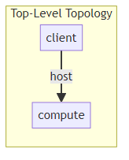

This example can be implemented using the following service template:

```yaml
tosca_definitions_version: tosca_2_0
imports:
- types.yaml
service_template:
  node_templates:
    compute:
      type: Compute
    client:
      type: ClientSoftware
      directives: [ substitute ]
      requirements:
      - host: compute
```

The following figure shows a substituting topology that *decomposes* the node of type "Client" into two software components, each of which needs to be hosted on the same "compute" node defined in the top-level template that defines the "client" node.

**Figure 23: Example Substitution for Client Deployed on Single Host**

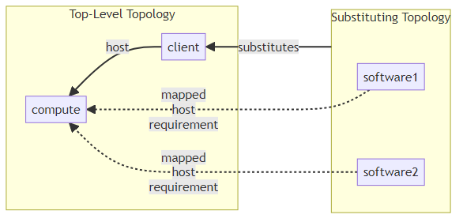

The requirement mapping syntax must *replicate* the single "host" requirements from the substituted "client" node to the two software nodes in the subsituting template. The substitution mapping code in the following substituting service template shows how this is accomplished by mapping the "host" requirement of the "client" node twice, once to the "host" requirement of the "software1" node and once to the "host" requirement of the "software2" node.

```yaml
tosca_definitions_version: tosca_2_0

imports:
- types.yaml

node_types:
  ClientSoftware:
    requirements:
      - host:
          capability: Host
          relationship: HostedOn
          count_range: [ 1, 1 ]

service_template:
  substitution_mappings:
    node_type: Client
    requirements:
      - host:
        - [ software1, host ]
        - [ software2, host ]

  node_templates:
    software1:
      type: ClientSoftware

    software2:
      type: ClientSoftware
```

Using this syntax, the target of the requirement mapping is a *list* of target requirements rather than a single requirement.

### 15.5.3 Requirement Mapping and Selectable Nodes

The previous section shows a use case where the target node of a requirement of the substituted node is to be used multiple times as the target node of *multiple different requirements* in a subsituting template. The need for multiple requirements to be fulfilled by the same target node is quite common and usually exists independently of whether the service template is used as a substitution or as a stand-alone service. In fact, the TOSCA *selectable node* feature was introduced specifically for scenarios where requirements of different nodes need to be fulfilled by the same target node.

The requirement mapping examples presented so far only show how to map requirements of a substituted node onto *dangling* requirements of nodes in the substituting template. This section shows how requirement mappings can also be used in conjunction with selectable nodes in substituting templates.

Let's again consider the scenario from the previous section where a node of type "Client" is hosted on a node of type "Compute":

**Figure 24: Client Deployed on Single Host**

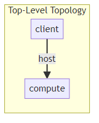

The following service template shows an implementation of this example:

```yaml
tosca_definitions_version: tosca_2_0

imports:
- types.yaml

service_template:
  node_templates:
    compute:
      type: Compute
    client:
      type: ClientSoftware
      directives: [ substitute ]
      requirements:
      - host: compute
```

The following figure shows a substituting topology that *decomposes* the node of type "Client" into two software components, each of which needs to be hosted on the same "compute" node. Unlike in the example in the previous section, a *selectable* node is used to express the need for both software components to be hosted on the same "compute" node:

**Figure 25: Substituting Template using Selectable Node**

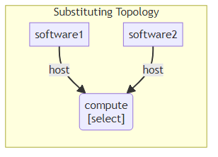

The requirement mappings defined in the corresponding service template must express that the target node of the "host" requirement of the substituted node is to be *selected* as the node represented by the *selectable* "compute" node in the subsituting template, as shown in the following Figure:

**Figure 26: Substitution with Requirement Mapping to Selectable Node**

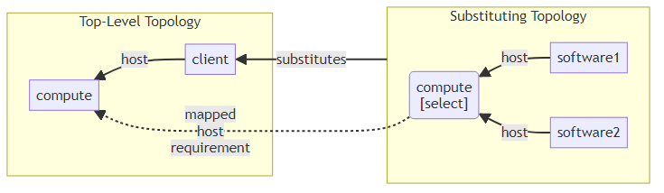

This can trivially be done using the syntax shown in the following code snippet:

```yaml
tosca_definitions_version: tosca_2_0

imports:
- types.yaml

service_template:
  substitution_mappings:
    node_type: Client
    requirements:
    - host: compute

  node_templates:
    software1:
      type: ClientSoftware
      requirements:
        - host: compute
    software2:
      type: ClientSoftware
      requirements:
        - host: compute
    compute:
      type: Compute
      directives: [select]
```

The substitution mapping code in this service template provides an elegant mechanism for expressing that the target node of the "host" requirement of the "client" node is to be mapped directly to the *selectable* "compute" node in the substituting template.

### 15.5.4 Requirement Mapping Rules

This section documents the rules for requirement mapping.

1. Requirements from a *substituted* node can only be mapped onto *dangling* requirements in the substituting template.
2. The total number of requirements mapped onto *mandatory* requirements in the substituting template must not exceed the lower bound of the `count_range` in the corresponding requirement definition in the substituted node's type.
3. The total number of requirement mappings must not exceed the upper bound of the `count_range` in the corresponding requirement definition in the substituted node's type. Note that this is a convenience rule only, since according to rule 2, any *excess* mappings would have to map onto optional requirements, and as a result can safely be ignored.

Note that there are no constraints on the minimum number of requirement mappings. More specifically, the total number of requirement mappings is allowed to be smaller than the lower bound of the `count_range` in the corresponding requirement definition.

The types defined in the following code snippet are used to illustrate these rules:

```yaml
tosca_definitions_version: tosca_2_0

imports:
- types.yaml

node_types:
  Client:
    requirements:
    - service:
        capability: Service
        relationship: ServedBy
        node: Server
        count_range: [ 1, 4 ]

  Server:
    capabilities:
      service:
        type: Service
```

In this example, the "Client" node type defines a "service" requirement with a `count_range` of `[1, 4]`. This means that a client can have up to four "service" connections to a "Server" node, but only one of those is mandatory.

The following code snippet shows a valid substituting template for the "client" node in the template shown above:

```yaml
tosca_definitions_version: tosca_2_0

imports:
  - types.yaml

node_types:
  ClientSoftware:
    requirements:
    - host:
        capability: Host
        relationship: HostedOn
    - service:
        capability: ServiceCapability
        relationship: Uses
        count_range: [ 1, 1 ]

  Compute:
    capabilities:
      host:
        type: Host

service_template:
  substitution_mappings:
    node_type: Client
    requirements:
      - service: [ software, service ]

  node_templates:
    software:
      type: ClientSoftware
      requirements:
      - host: compute

    compute:
      type: Compute
```

While the substituted "client" node in the template above has three requirement assigments with target nodes, only one of those requirements is mapped to a requirement in the substituting template.

The next code snippet shows a slightly different substituting template for the "client" node in the template shown above. This template *decomposes* the "client" node into three different software nodes, each with a single "service" requirement to its own server. The substitution mapping defines three requirement mappings for the "service" requirement of the "client" node, one to each of the "service" requirements of the "software" nodes in the substituting template.

```yaml
tosca_definitions_version: tosca_2_0

imports:
- types.yaml

node_types:
  ClientSoftware:
    requirements:
    - host:
        capability: Host
        relationship: HostedOn
    - service:
        capability: ServiceCapability
        relationship: Uses
        count_range: [ 1, 1 ]

  Compute:
    capabilities:
      host:
        type: Host

service_template:
  substitution_mappings:
    node_type: Client
    requirements:
    - service: [ software1, service ]
    - service: [ software2, service ]
    - service: [ software3, service ]

  node_templates:
    software1:
      type: ClientSoftware
      requirements:
      - host: compute1

    software2:
      type: ClientSoftware
      requirements:
      - host: compute2

    software3:
      type: ClientSoftware
      requirements:
      - host: compute3

    compute1:
      type: Compute

    compute2:
      type: Compute

    compute3:
      type: Compute
```

Unfortunately, this substituting template is invalid. Since the "service" requirement of each "software" node is mandatory, this template needs three different "service" requirements in any node of type "Client" for which it is a substitution. This cannot be guaranteed, since the "service" requirement definition in the "Client" node type specifies a `count_range` with a lower bound of one, which means that only such requirement is guaranteed to exist.

The following shows a corrected version of this substituting template:

```yaml
tosca_definitions_version: tosca_2_0

imports:
- types.yaml

node_types:
  ClientSoftware:
    requirements:
    - host:
        capability: Host
        relationship: HostedOn
    - service:
        capability: ServiceCapability
        relationship: Uses
        count_range: [ 0, 1 ]

  Compute:
    capabilities:
      host:
        type: Host

service_template:
  substitution_mappings:
    node_type: Client
    requirements:
    - service: [ software1, service ]
    - service: [ software2, service ]
    - service: [ software3, service ]

  node_templates:
    software1:
      type: ClientSoftware
      requirements:
      - host: compute1
      - service:
          optional: false

    software2:
      type: ClientSoftware
      requirements:
      - host: compute2

    software3:
      type: ClientSoftware
      requirements:
      - host: compute3

    compute1:
      type: Compute

    compute2:
      type: Compute

    compute3:
      type: Compute
```

In this template, the "service" requirement of the "ClientSoftware" node type is defined with a `count_range` of "[0, 1]", which means the requirement is no longer mandatory. Only the "software1" node template annotates its "service" requirement as mandatory (using the `optional: false` statement). The other two software nodes leave their "service" requirement optional. As a result, this is now a valid substituting template for nodes of type "Client" that define a "service" requirement with `count_range` equal to "[1, 4]".

Requirement mapping must take one more rule into account: if the number of requirement mappings is greater than the lower bound of the `count_range`, the orchestrator must first perform those mappings that map requirements onto non-optional requirements in the substituting template, and then it will perform the remaining mappings (which presumably will map onto optional requirements in the substituting template). This is done independent of the order in which the requirement mappings are specified.

### 15.5.5 Handling `UNBOUNDED` Requirement Count Ranges

In the case of `UNBOUNDED` count ranges, we must use unbounded grammar forms.

In the following case all "service" requirements of the substituted node are mapped to the corresponding "service" requirements of the "software1" node in the substituting template. This allows for the follwing compact syntax:

```yaml
tosca_definitions_version: tosca_2_0

imports:
- types.yaml

node_types:
  Client:
    requirements:
    - service:
        capability: Service
        relationship: ServedBy
        node: Server
        count_range: [ 3, UNBOUNDED ]

  ClientSoftware:
    requirements:
    - host:
        capability: Host
        relationship: HostedOn
    - service:
        capability: Service
        relationship: ServedBy
        count_range: [ 0, UNBOUNDED ]

  Compute:
    capabilities:
      host:
        type: Host

  Server:
    capabilities:
      service:
        type: Service
service_template:
  substitution_mappings:
    node_type: Client
    requirements:
    - service: [ software1, service ]

  node_templates:
    software1:
      type: ClientSoftware
      requirements:
      - host: compute

    software2:
      type: ClientSoftware
      requirements:
      - host: compute

    compute:
      type: Compute
```

In the next case the "service" requirements of the substituted node are mapped to the corresponding "service" requirements of both the "software1" and "software2" nodes in the substituting template as follows: the first requirement assignment is mapped to the "service" requirement of the "software1" node, the second requirement assignment is mapped to the "service" requirement of the "software2" node, then the rest of the "service" requirements of the substituted node are mapped again to the "service" requirement of the "software1" node:

```yaml
tosca_definitions_version: tosca_2_0

imports:
- types.yaml

node_types:
  Client:
    requirements:
    - service:
        capability: Service
        relationship: ServedBy
        node: Server
        count_range: [ 3, UNBOUNDED ]

  ClientSoftware:
    requirements:
    - host:
        capability: Host
        relationship: HostedOn
    - service:
        capability: Service
        relationship: ServedBy
        count_range: [ 0, UNBOUNDED ]

  Compute:
    capabilities:
      host:
        type: Host

service_template:
  substitution_mappings:
    node_type: Client
    requirements:
    - service: [ software1, service ]
    - service: [ software2, service ]
    - [ service, UNBOUNDED ]: [ software1, service ]

  node_templates:
    software1:
      type: ClientSoftware
      requirements:
      - host: compute

    software2:
      type: ClientSoftware
      requirements:
      - host: compute

    compute:
      type: Compute
```

## 15.6 Interface Mapping

An *interface mapping* allows an interface operation on the substituted node to be mapped to workflow in the substituting service template.

The grammar of an interface mapping is as follows:

```yaml
<interface_name>:
  <operation_name>: <workflow_name>
```

In the above grammar, the placeholders that appear in angle brackets have the following meaning:

- `<interface_name>`: represents the name of the interface as it appears in the node type definition for the node type (name) that is declared as the value for on the substitution_mappings' `node_type` key.
- `<operation_name>`: represents the name of the operation as it appears in the interface type definition for `<interface_name>`.
- `<workflow_name>`: represents the name of a workflow defined in the substituting service template to which to map the specified interface operation.

# 16 Groups and Policies

A *group* is a logical grouping of nodes for purposes of uniform application of *policies* to collections of nodes. Conceptually, group definitions allow the creation of logical *membership* relationships to nodes in a service template that are not a part of the application's explicit requirement dependencies in the topology template (i.e. those required to actually get the application deployed and running).

The content in this section is normative unless otherwise labeled except:

- the examples
- references unless labelled as normative.

## 16.1 Group Type

As with most TOSCA entities, groups are typed. A group type definition is a type of TOSCA type definition and as a result supports the common keynames listed in the section Common Keynames in Type Definitions . In addition, the group type definition has the following recognized keynames:

| Keyname | Mandatory | Type | Description |
| --- | --- | --- | --- |
| `properties` | no | map of property definitions | An optional map of property definitions for the group type. |
| `attributes` | no | map of attribute definitions | An optional map of attribute definitions for the group type. |
| `members` | no | seq of strs | An optional list of one or more names of node types that are valid (allowed) as members of the group type. |

Group types have the following grammar:

```yaml
<group_type_name>:
  derived_from: <parent_group_type_name>
  version: <version_number>
  metadata:
    <metadata_name_1>: <metadata_value_1>
    <metadata_name_2>: <metadata_value_2>
    ...
  description: <group_description>
  properties:
    <property_def_1>
    <property_def_2>
    ...
  attributes:
    <attribute_def_1>
    <attribute_def_2>
    ...
  members: [ <valid_member_type_1>, <valid_member_type_1>, ... ]
```

In the above grammar, the placeholders that appear in angle brackets have the following meaning:

- `<group_type_name>`: represents the mandatory symbolic name of the Group Type being declared as a string.
- `<parent_group_type_name>`: represents the name (string) of the group type this group type definition derives from (i.e. its "parent" type).
- `<attribute_def_*>`: represents the optional map of attribute definitions for the group type.
- `<property_def_*>`: represents the optional map of property definitions for the group type.
- `<valid_member_type_*>`: represents the optional list of TOSCA Node Types that are valid member types for being added to (i.e. members of) the group type; if the `members` keyname is not defined then there are no restrictions to the member types;
  - note that the members of a group ultimately resolve to nodes, the types here just restrict which nodes can be defined as members in a group definition.
  - A node type is matched if it is the specified type or is derived from the node type

During group type derivation the keyname definitions follow these rules:

- `properties`: existing property definitions may be refined; new property definitions may be added.
- `attributes`: existing attribute definitions may be refined; new attribute definitions may be added.
- `members`: if the `members` keyname is defined in the parent type, each element in this list must either be in the parent type list or derived from an element in the parent type list; if the `members` keyname is not defined in the parent type then no restrictions are applied to the definition.

The following represents an example group type definition:

```yaml
group_types:
  Placement:
    description: My company's group type for placing nodes of type Software
    members: [ Software ]
```

## 16.2 Group Definition

Collections of nodes in a service template may be grouped together using a *group definition* in that same service template. A group definition defines a logical grouping of node templates for purposes of uniform application of policies.

The following is the list of recognized keynames for a group definition:

| Keyname | Mandatory | Type | Description |
| --- | --- | --- | --- |
| `type` | yes | str | The mandatory name of the group type the group definition is based upon. |
| `description` | no | str | The optional description for the group definition. |
| `metadata` | no | map of metadata | Defines a section used to declare additional information. |
| `properties` | no | map of property assignments | An optional map of property value assignments for the group definition. |
| `attributes` | no | map of attribute assignments | An optional map of attribute value assignments for the group definition. |
| `members` | no | seq of strs | The optional list of one or more node template names that are members of this group definition. |

Group definitions have one the following grammars:

```yaml
<group_name>:
  type: <group_type_name>
  description: <group_description>
  metadata:
    <metadata_name_1>: <metadata_value_1>
    <metadata_name_2>: <metadata_value_2>
    ...
  properties:
    <property_assignment_1>
    <property_assignment_2>
    ...
  attributes:
    <attribute_assignment_1>
    <attribute_assignment_2>
    ...
  members: [ <node_template_1>, <node_template_2>, ... ]
```

In the above grammar, the placeholders that appear in angle brackets have the following meaning:

- `<group_name>`: represents the mandatory symbolic name of the group as a string.
- `<group_type_name>`: represents the name of the group type the definition is based upon.
- `<property_assignment_*>`: represents the optional map of property assignments for the group definition that provide values for properties defined in its declared group type.
- `<attribute_assigment_*>`: represents the optional map of attribute assignments for the group definition that provide values for attributes defined in its declared group type.
- `<node_template_*>`: contains the mandatory list of one or more node template names or group symbolic names (within the same service template) that are members of this logical group
  - if the `members` keyname was defined (by specifying a `<valid_member_type_*>`) in the group type of this group then the nodes listed here must be compatible (i.e. be of that type or of type that is derived from) with the node types in the `<valid_member_type_*>`

The following represents a group definition:

```yaml
  groups:
    my-app-placement:
      type: Placement
      description: My application's logical component grouping for placement
      members: [ my-web-server, my-sql-database ]
```

## 16.3 Policy Type

A *policy type* defines a type of a policy that affects or governs an application or service's topology at some stage of its lifecycle but is not explicitly part of the topology itself (i.e., it does not prevent the application or service from being deployed or run if it did not exist).

A policy type definition is a type of TOSCA type definition and as a result supports the common keynames listed in the section Common Keynames in Type Definitions . In addition, the policy type definition has the following recognized keynames:

| Keyname | Mandatory | Type | Description |
| --- | --- | --- | --- |
| `properties` | no | map of property definitions | An optional map of property definitions for the policy type. |
| `targets` | no | seq of strs | An optional list of valid node types or group types the policy type can be applied to. |
| `triggers` | no | map of trigger definitions | An optional map of policy triggers for the policy type. |

Policy types have the following grammar:

```yaml
<policy_type_name>:
  derived_from: <parent_policy_type_name>
  version: <version_number>
  metadata:
    <metadata_name_1>: <metadata_value_1>
    <metadata_name_2>: <metadata_value_2>
    ...
  description: <policy_description>
  properties:
    <property_def_1>
    <property_def_2>
    ...
  targets: [ <valid_target_type_1>, <valid_target_type_2>, ... ]
  triggers:
    <trigger_def_1>
    <trigger_def_2>
    ...
```

In the above grammar, the placeholders that appear in angle brackets have the following meaning:

- `<policy_type_name>`: represents the mandatory symbolic name of the policy type being declared as a string.
- `<parent_policy_type_name>`: represents the name (string) of the policy type this policy type definition derives from (i.e., its "parent" type).
- `<property_def_*>`: represents the optional map of property definitions for the policy type.
- `<valid_target_type_*>`: represents the optional list of TOSCA types (i.e. group or node types) that are valid targets for this policy type; if the `targets` keyname is not defined then there are no restrictions to the targets' types.
- `<trigger_def_*>`: represents the optional map of trigger definitions for the policy.

During policy type derivation the keyname definitions follow these rules:

- `properties`: existing property definitions may be refined; new property definitions may be added.
- `targets`: if the `targets` keyname is defined in the parent type, each element in this list must either be in the parent type list or derived from an element in the parent type list; if the `targets` keyname is not defined in the parent type then no restrictions are applied to this definition.
- `triggers`: existing trigger definitions may not be changed; new trigger definitions may be added.

The following represents a policy type definition:

```yaml
policy_types:
  Placement.Container.Linux:
    description: My company's placement policy for linux
```

## 16.4 Policy Definition

A *policy definition* defines a policy that can be associated with a TOSCA service or top-level entity definition (e.g., group definition, node template, etc.).

The following is the list of recognized keynames for a TOSCA policy definition:

[output not shown]

Policy definitions have the following grammar:

```yaml
<policy_name>:
  type: <policy_type_name>
  description: <policy_description>
  metadata:
    <metadata_name_1>: <metadata_value_1>
    <metadata_name_2>: <metadata_value_2>
    ...
  properties:
    <property_assignment_1>
    <property_assignment_2>
    ...
  targets: [ <policy_target_1>, <policy_target_2>, ... ]
  triggers:
    <trigger_def_1>
    <trigger_def_2>
    ...
```

In the above grammar, the placeholders that appear in angle brackets have the following meaning:

- `<policy_name>`: represents the mandatory symbolic name of the policy as a string.
- `<policy_type_name>`: represents the name of the policy the definition is based upon.
- `<property_assignment_*>`: represents the optional map of property assignments for the policy definition that provide values for properties defined in its declared policy type.
- `<policy_target_*>`: represents the optional list of names of node templates or groups that the policy is to applied to.
  - if the `targets` keyname was defined (by specifying a `<valid_target_type_*>`) in the policy type of this policy then the targets listed here must be compatible (i.e. be of that type or of type that is derived from) with the types (of nodes or groups) in the `<valid_target_type_*>`.
- `<trigger_def_*>`: represents the optional map of trigger definitions for the policy; these triggers apply in addition to the triggers defined in the policy type.

The following represents a policy definition:

```yaml
    - my-compute-placement:
        type: Placement
        description: Apply my placement policy to my application's servers
        targets: [ my_server_1, my_server_2 ]
        # remainder of policy definition omitted for brevity
```

## 16.5 Trigger Definition

A *trigger definition* defines an *event, condition, action* tuple associated with a policy.

The following is the list of recognized keynames for a TOSCA trigger definition:

| Keyname | Mandatory | Type | Description |
| --- | --- | --- | --- |
| `description` | no | str | The optional description string for the trigger. |
| `event` | yes | str | The mandatory name of the event that activates the trigger's action. |
| `condition` | no | condition clause | The optional condition that must evaluate to true in order for the trigger's action to be performed. Note: this is optional since sometimes the event occurrence itself is enough to trigger the action. |
| `action` | yes | seq of activity definitions | The list of sequential activities to be performed when the event is triggered, and the condition is met (i.e., evaluates to true). |

Trigger definitions have the following grammars:

```yaml
<trigger_name>:
  description: <trigger_description>
  event: <event_name>
  condition: <condition_clause>
  action:
  - <activity_def_1>
  - <activity_def_2>
  - ...
```

In the above grammar, the placeholders that appear in angle brackets have the following meaning:

- `<trigger_name>`: represents the mandatory symbolic name of the trigger as a string.
- `<event_name>`: represents the mandatory name of an event associated with an interface notification on the identified resource (node).
- `<condition_clause>`: an optional Boolean expression that can be evaluated within the context of the service with which the policy is associated and that must evaluate to true in order for the trigger's action to be performed. Note that the arguments to the condition clause function can in turn be other TOSCA functions. If no condition clause is specified, the trigger event will always result in the trigger's action being taken.
- `<activity_def_*>`: represents the list of activities that are performed in response to the event if the (optional) condition is met.

# 17 Cloud Service Archive (CSAR) Format

This section defines the metadata of a cloud service archive as well as its overall structure.

The content in this section is normative unless otherwise labeled except:

- the examples
- references unless labelled as normative.

## 17.1 Overall Structure of a CSAR

A CSAR is a package of files containing at least TOSCA definitions as well as accompanying artifacts (e.g. scripts, binaries, configuration files) that can be delivered together as a single unit.

CSARs can be used to package service templates and/or profiles.

The service template or profile root TOSCA YAML file can be specified in one of two ways:

- If a `TOSCA.meta` file is present (see below) it may specify the root TOSCA YAML file. The `TOSCA.meta` file may be located either at the root of the archive or inside a "TOSCA-Metadata" directory. The CSAR may contain only one `TOSCA.meta` file.
- Otherwise, if a single valid TOSCA YAML file (named with a ".yaml" or ".yml" extension) is located at the root of the archive, it will be used as the root TOSCA YAML file.

The CSAR file may contain other directories and files with arbitrary names and content.

### 17.1.1 CSAR Archiving Formats

While any archiving method that maintains a file and directory structure can be used, two formats are specifically supported, tarballs and Zip files.

#### 17.1.1.1 Tarballs

These are optionally compressed streams generated by the "tar" (tape archive) command available on most operating systems. TOSCA at minimum supports uncompressed tarballs (named with a ".tar" extension) as well tarballs compressed with Gzip (named with a ".tar.gz" or ".tgz" extension). Other compression algorithms may also be optional supported.

Because tarballs are organized sequentially, their contents can be efficiently streamed from a filesystem or a network server with minimal buffering and no need to store data local storage. For example, if only a single file in the tarball is needed, a client can skip other entries and read only that file.

The supported tar format is UStar, as specified in [POSIX IEEE P1003.1](https://archive.org/details/mac_Internet_File_Formats_1995/page/n201/mode/2up). Gzip 4.3 is specified in [IETF RFC-1952](https://datatracker.ietf.org/doc/html/rfc1952).

#### 17.1.1.2 Zip Files

These are optionally compressed files relying on random access to entries. Files should be named with a ".zip" or a ".csar" extension.

Note that the ".csar" extension has been used in previous versions of TOSCA to refer *exclusively* to Zip files. It is recommended to use the ".zip" extension instead in order to clarify and differentiate the archiving formats.

Because Zip files require random access, the archive must be accessible in its entirety by clients, usually in a local file system. If it necessary to support clients with no access to local storage, tarballs may be preferred instead.

The Zip format supported by TOSCA is specified in [ISO/IEC 21320-1 "Document Container File — Part 1: Core"](https://www.iso.org/standard/60101.html).

## 17.2 `TOSCA.meta` File

A `TOSCA.meta` file consists of keyname/value pairs. The keyname of a keyname/value pair is followed by a colon, followed by a space, followed by the value of the keyname/value pair. The keyname MUST NOT contain a colon. Values that represent binary data MUST be base64 encoded. Values that extend beyond one line can be spread over multiple lines if each subsequent line starts with at least one space. Such spaces are then collapsed when the value string is read.

```
<keyname>: <value>
```

Each keyname/value pair is in a separate line. A list of related keyname/value pairs, i.e. a list of consecutive keyname/value pairs is called a block. Blocks are separated by an empty line. The first block, called "block_0", contains metadata about the CSAR itself and is further defined below. Other blocks may be used to represent custom generic metadata or metadata pertaining to files in the CSAR. A `TOSCA.meta` file is only required to include "block_0".

### 17.2.1 Block 0 Keynames in the `TOSCA.meta` File

The structure of "block_0" in the `TOSCA.meta` file is as follows:

```
CSAR-Version: digit.digit
Created-By: string
Entry-Definitions: string
Other-Definitions: string
```

The keyname/value pairs are as follows:

- `CSAR-Version`: This is the version number of the CSAR specification. It defines the structure of the CSAR and the format of the `TOSCA.meta` file. The value MUST be "2.0" for this version of the CSAR specification.
- `Created-By`: The person or organization that created the CSAR.
- `Entry-Definitions`: This references the TOSCA definitions file that SHOULD be used as entry point for processing the contents of the CSAR (e.g. the main TOSCA service template).
- `Other-Definitions`: This references an unambiguous set of files containing substitution templates that can be used to implement nodes defined in the main template (i.e. the file declared in `Entry-Definitions`). Thus, all the service templates defined in files listed under the `Other-Definitions` key are to be used only as substitution templates, and not as standalone services. If such a service template cannot act as a substitution template, it will be ignored by the orchestrator. The value of the `Other-Definitions` key is a string containing a list of filenames (relative to the root of the CSAR archive) delimited by a blank space. If the filenames contain blank spaces, the filename should be enclosed by double quotation marks (").

Note that any further TOSCA definitions files required by the definitions specified by `Entry-Definitions` or `Other-Definitions` can be found by a TOSCA orchestrator by processing respective `imports` keynames. Note also that artifact files (e.g. scripts, binaries, configuration files) used by the TOSCA definitions and included in the CSAR are fully described and referred via relative path names in artifact definitions in the respective TOSCA definitions files contained in the CSAR.

The following listing represents a valid `TOSCA.meta` file according to this TOSCA specification.

```
CSAR-Version: 2.0
Created-By: OASIS TOSCA TC
Entry-Definitions: tosca_elk.yaml
Other-Definitions: definitions/tosca_moose.yaml definitions/tosca_deer.yaml
```

This `TOSCA.meta` file indicates its structure (as well as the overall CSAR structure) by means of the `CSAR-Version` keyname with value "2.0". The `Entry-Definitions` keyname points to a TOSCA definitions YAML file with the name "tosca_elk.yaml" which is contained in the root of the CSAR file. Additionally, it specifies that substitution templates can be found in the files "tosca_moose.yaml" and "tosca_deer.yaml" found in the directory called "definitions" in the root of the CSAR file.

### 17.2.2 Custom Keynames in the `TOSCA.meta` File

Users can populate other blocks than "block_0" in the `TOSCA.meta` file with custom name/value pairs that follow the entry syntax defined above and have names that are different from the normative keynames (e.g. `CSAR-Version`, `Created-By`, `Entry-Definitions`, `Other-Definitions`). These custom name/value pairs are outside the scope of the TOSCA specification. Nevertheless, future versions of the TOSCA specification may add definitions of new keynames to be used in the `TOSCA.meta` file. In case of a keyname collision (with a custom keyname) the TOSCA specification definitions take precedence.

To minimize such keyname collisions the specification reserves the use of keynames prefixed with "TOSCA" and "tosca". It is recommended as a good practice to use a specific prefix (e.g. identifying the organization, scope, etc.) when using custom keynames.

## 17.3 CSAR Without a `TOSCA.meta` File

In case the archive doesn't contains a `TOSCA.meta` file the archive is required to contains a single YAML file at the root of the archive (other templates may exist in sub-directories).

TOSCA processors should recognize this file as being the CSAR Entry-Definitions file. The `CSAR-Version` is inferred from the `tosca_definitions_version` keyname in the `Entry-Definitions` file. For `tosca_definitions_version: tosca_2_0` and onwards, the corresponding `CSAR-Version` is "2.0" unless further defined.

Note that in a CSAR without a `TOSCA.meta` file it is not possible to unambiguously include definitions for substitution templates as we can have only one service template defined in a YAML file.

The following represents a valid TOSCA template file acting as the CSAR `Entry-Definitions` file in an archive without a `TOSCA.meta` file.

```yaml
tosca_definitions_version: tosca_2_0

metadata:
  template_name: my_template
  template_author: OASIS TOSCA TC
  template_version: '1.0'
```

# 18 Conformance

The content in this section is normative unless otherwise labeled except:

- the examples
- references unless labelled as normative.

## 18.1 Conformance Targets

The implementations subject to conformance are listed here:

- TOSCA file
- TOSCA processor
- TOSCA orchestrator
- TOSCA generator
- TOSCA archive

## 18.2 Conformance Clause 1: TOSCA File

A document conforms to this specification as a TOSCA file if it satisfies all the statements below:

1. It is valid according to the grammar, rules and requirements defined in TOSCA File Definition.
2. When using functions defined in TOSCA Functions, it is valid according to the grammar specified for these functions.
3. When defining entities that use data types, artifact types, capability types, interface types, node types, relationship types, group types, or policy types, these entity definitions are valid according to the definitions given in:
   - Node Type
   - Relationship Type
   - Capability Type
   - Data Type
   - Interface Type
   - Artifact Type
   - Group Type
   - Policy Type

## 18.3 Conformance Clause 2: TOSCA Processor

A processor or program conforms to this specification as TOSCA processor if it satisfies all the statements below:

1. It can parse and recognize the elements of any conforming TOSCA file and generates errors for those documents that fail to conform as a TOSCA file while clearly intending to.
2. It implements the requirements and semantics associated with the definitions and grammar in Sections 5 through 16, including those listed in the *additional requirements* paragraphs.
3. It resolves the imports as described in Import Definitions
4. It generates errors as required in error cases described in Namespaces, TOSCA Built-In Types and the type specific definitions in
   - Node Type
   - Relationship Type
   - Capability Type
   - Data Type
   - Interface Type
   - Artifact Type
   - Group Type
   - Policy Type

## 18.4 Conformance Clause 3: TOSCA Orchestrator

A processor or program conforms to this specification as a TOSCA orchestrator if it satisfies all the statements below:

1. It can process TOSCA archives as intended in Cloud Service Archive (CSAR) Format and other related normative sections.
2. It is conforming as a TOSCA Processor as defined in Conformance Clause 2: TOSCA Processor.
3. It can understand and process the functions defined in TOSCA Functions according to their rules and semantics.
4. It can fulfill dangling requirements as defined in Requirement Assignment, including requirement assignments created automatically for mandatory requirements. It can properly apply node filters as defined in Node Filter Definition to select appropriate target node candidates for fulfulling requirements.
5. It can generate substituting services for substitutable nodes as defined in Substitution. It can properly apply substitution filters as defined in Substitution Mapping to select valid substituting service template candidates based on which to create the substituting service.
6. It can process artifacts used as operation implementations as described in Operation Assignment. Orchestrators are expected to process implementing artifacts based on their type as defined in Artifact Type.

## 18.5 Conformance Clause 4: TOSCA Generator

A processor or program conforms to this specification as a TOSCA generator if it satisfies at least one of the statements below:

1. When requested to generate a TOSCA file, it always produces a conforming TOSCA file as defined in Conformance Clause 1: TOSCA File.
2. When requested to generate a TOSCA archive, it always produces a conforming TOSCA archive as defined in Conformance Clause 5: TOSCA Archive

## 18.6 Conformance Clause 5: TOSCA Archive

A package artifact conforms to this specification as TOSCA archive if it satisfies all the statements below:

1. It is valid according to the structure and rules defined in Cloud Service Archive (CSAR) Format.

# Appendix A. References

This appendix contains the normative and informative references that are used in this document.

While any hyperlinks included in this appendix were valid at the time of publication, OASIS cannot guarantee their long-term validity.

## A.1 Normative References

The following documents are referenced in such a way that some or all of their content constitutes requirements of this document.

###### [RFC2119]

Bradner, S., "Key words for use in RFCs to Indicate Requirement Levels", BCP 14, RFC 2119, DOI 10.17487/RFC2119, March 1997, http://www.rfc-editor.org/info/rfc2119.

###### [RFC8174]

Leiba, B., "Ambiguity of Uppercase vs Lowercase in RFC 2119 Key Words", BCP 14, RFC 8174, DOI 10.17487/RFC8174, May 2017, http://www.rfc-editor.org/info/rfc8174.

###### [YAML-1.2]

YAML, Version 1.2, 3rd Edition, Patched at 2009-10-01, Oren Ben-Kiki, Clark Evans, Ingy döt Net

## A.2 Informative References

###### [Maven-Version]

Apache Maven version policy draft: https://cwiki.apache.org/confluence/display/MAVEN/Version+number+policy

###### [RFC3552]

Rescorla, E. and B. Korver, "Guidelines for Writing RFC Text on Security Considerations", BCP 72, RFC 3552, DOI 10.17487/RFC3552, July 2003, https://www.rfc-editor.org/info/rfc3552.

###### [File Extensions for Media Types]

File extensions for media types some registered as described in RFC 4288 http://svn.apache.org/repos/asf/httpd/httpd/trunk/docs/conf/mime.types

###### [TOSCA Discussion]

tosca-community-contributions github repository. https://github.com/oasis-open/tosca-community-contributions

###### [RFC3339]

G. Klyne and C, Newman "Date and Time on the Internet: Timestamps" July 2002, https://tools.ietf.org/html/rfc3339

###### [SI Units]

"*SI Brochure: The International System of Units (SI) [8th edition, 2006; updated in 2014]*", http://www.bipm.org/en/publications/si-brochure/